# Capstone Project: Create a Customer Segmentation Report for Arvato Financial Services

To investigate the features, you should map each weight to their corresponding feature name, then sort the features according to weight. The most interesting features for each principal component, then, will be those at the beginning and end of the sorted list. Use the data dictionary document to help you understand these most prominent features, their relationships, and what a positive or negative value on the principal component might indicate. You should investigate and interpret feature associations from the first three principal components in this substep. To help facilitate this, you should write a function that you can call at any time to print the sorted list of feature weights, for the i-th principal component. This might come in handy in the next step of the project, when you interpret the tendencies of the discovered clusters.

```python
# Map weights for the first principal component to corresponding feature names
# and then print the linked values, sorted by weight.
# HINT: Try defining a function here or in a new cell that you can reuse in the
# other cells.

# The pca_results function was taken from the class notes and altered

def pca_results(full_dataset, pca, component_number):
    '''
    Create a DataFrame of the PCA results
    Includes dimension feature weights and explained variance
    Visualizes the PCA results where figure 1 shows all features sorted
    and figure 2 shows the top 3 negative and positive features.
    '''

    # Dimension indexing
    dimensions = dimensions = ['Dimension {}'.format(i) for i in range(1,len(pca.components_)+1)]

    # PCA components
    components = pd.DataFrame(np.round(pca.components_, 4), columns = full_dataset.keys())
    components.index = dimensions

    # PCA explained variance
    ratios = pca.explained_variance_ratio_.reshape(len(pca.components_), 1)
    variance_ratios = pd.DataFrame(np.round(ratios, 4), columns = ['Explained Variance'])
    variance_ratios.index = dimensions

    # Create a bar plot visualization for 1st figure (all columns sorted)
    fig1, ax1 = plt.subplots(figsize = (15,8))

    # Plot the feature weights as a function of the components
    components.iloc[component_number-1, :].sort_values().plot(ax = ax1, kind = 'bar');
    ax1.set_ylabel("Feature Weights")
    ax1.set_xticklabels(components.iloc[component_number-1, :].sort_values().index, rotation=90)

    # Create a bar plot visualization for 2nd figure (top and bottom 3 columns)
    fig2, ax2 = plt.subplots(figsize = (6,3))

    # Plot the feature weights as a function of the components
    components.iloc[component_number-1, :].sort_values().iloc[[0, 1, 2, -3, -2, -1]].plot(ax = ax2, kind = 'bar');
    ax2.set_ylabel("Feature Weights")
    ax2.set_xticklabels(components.iloc[component_number-1, :].sort_values().index, rotation=90)

    # Return a concatenated DataFrame
    return pd.concat([variance_ratios, components], axis = 1)
```

|  | Explained Variance | LNR | AGER_TYP | AKT_DAT_KL | ANZ_KINDER | ANZ_PERSONEN | ANZ_TITEL | CJT_GESAMTTYP | CJT_KATALOGNUTZER | CJT_TYP_1 | ... | UNGLEICHENN_FLAG | VERS_TYP | VHA | VK_DHT4A | VK_DISTANZ | VK_ZG11 | WOHNDAUER_2008 | ZABEOTYP | ANREDE_KZ | ALTERSKATEGORIE_GROB |
| --- | --- | --- | --- | --- | --- | --- | --- | --- | --- | --- | --- | --- | --- | --- | --- | --- | --- | --- | --- | --- | --- |
| Dimension 1 | 0.1430 | -0.0012 | 0.0480 | -0.1096 | 0.0616 | 0.1434 | 0.0050 | -0.0079 | -0.0858 | -0.0416 | ... | 0.0214 | 0.0753 | 0.0856 | -0.1852 | -0.1835 | -0.1552 | 0.0125 | -0.0735 | -0.0142 | 0.0216 |
| Dimension 2 | 0.1163 | 0.0037 | -0.1489 | 0.0648 | 0.0618 | 0.0170 | -0.0087 | 0.1047 | -0.1372 | 0.2224 | ... | 0.0292 | -0.0066 | -0.0262 | -0.0503 | 0.0092 | 0.0638 | -0.0821 | 0.0826 | 0.0153 | -0.2002 |
| Dimension 3 | 0.0555 | -0.0095 | 0.0123 | 0.0122 | -0.0312 | -0.0214 | 0.0027 | -0.0250 | 0.1504 | -0.0839 | ... | -0.0053 | 0.0798 | -0.0287 | 0.0386 | 0.0078 | -0.0441 | 0.0016 | -0.0205 | -0.3461 | -0.0314 |
| Dimension 4 | 0.0485 | 0.0210 | -0.0611 | -0.0473 | 0.0404 | 0.1200 | 0.0122 | 0.1385 | 0.0844 | 0.0730 | ... | 0.0360 | -0.3141 | 0.0520 | -0.1005 | -0.1123 | -0.1128 | 0.0432 | -0.1334 | -0.0646 | -0.0525 |
| Dimension 5 | 0.0325 | -0.0378 | 0.0822 | -0.0942 | -0.0532 | -0.1592 | -0.0177 | 0.0468 | 0.1409 | -0.0123 | ... | -0.1234 | -0.0962 | 0.0058 | -0.0481 | -0.0500 | -0.0396 | -0.1888 | 0.0659 | -0.0384 | 0.0477 |
| Dimension 6 | 0.0252 | -0.0507 | 0.0722 | 0.0851 | 0.0001 | 0.2065 | 0.0071 | -0.0190 | 0.0723 | -0.0118 | ... | 0.1036 | -0.0376 | 0.0940 | -0.0015 | -0.0603 | -0.0925 | 0.1699 | 0.0819 | 0.0047 | -0.0137 |
| Dimension 7 | 0.0210 | -0.0005 | 0.0328 | 0.0013 | -0.0957 | -0.1500 | 0.0215 | -0.0002 | -0.0057 | 0.0325 | ... | -0.1683 | 0.0255 | 0.0912 | 0.0845 | 0.0383 | -0.0084 | 0.0746 | -0.0407 | 0.0221 | -0.0752 |
| Dimension 8 | 0.0178 | 0.0499 | -0.1183 | 0.0961 | -0.0296 | -0.0137 | -0.0367 | -0.0224 | 0.0043 | 0.0079 | ... | -0.0826 | 0.0046 | -0.0379 | 0.1443 | 0.1590 | 0.1510 | 0.0476 | -0.0262 | -0.0125 | 0.0501 |
| Dimension 9 | 0.0149 | -0.0107 | 0.2292 | -0.1049 | -0.1189 | -0.0423 | 0.0856 | -0.0334 | -0.0296 | -0.0779 | ... | -0.0800 | -0.0033 | 0.0538 | 0.0095 | -0.0247 | -0.0348 | 0.1412 | 0.0159 | 0.0892 | -0.2338 |
| Dimension 10 | 0.0137 | 0.0459 | -0.0391 | 0.0423 | -0.0244 | 0.0115 | 0.6712 | -0.0023 | 0.0043 | 0.0134 | ... | 0.0240 | 0.0123 | -0.0469 | 0.0042 | -0.0103 | -0.0117 | -0.0366 | -0.0383 | -0.0054 | 0.0315 |
| Dimension 11 | 0.0134 | -0.0032 | 0.0497 | 0.0212 | -0.0020 | 0.0103 | -0.0601 | -0.0818 | 0.0106 | -0.0516 | ... | -0.0211 | 0.0287 | -0.0752 | -0.0140 | -0.0006 | 0.0113 | -0.1179 | -0.0209 | 0.0278 | -0.0841 |
| Dimension 12 | 0.0128 | 0.0468 | 0.0217 | 0.0738 | 0.0678 | 0.0283 | 0.0542 | -0.0432 | -0.0078 | -0.1014 | ... | 0.1247 | -0.0200 | -0.1169 | 0.0302 | 0.0923 | 0.1351 | -0.2560 | 0.0490 | -0.0164 | -0.0626 |
| Dimension 13 | 0.0119 | -0.3555 | -0.0446 | -0.1034 | 0.1732 | -0.0490 | 0.1301 | 0.0971 | -0.0921 | 0.0283 | ... | 0.0191 | -0.0545 | 0.1481 | -0.0835 | -0.0802 | -0.0657 | -0.0215 | 0.2112 | -0.0595 | 0.0663 |
| Dimension 14 | 0.0115 | -0.1088 | -0.1410 | 0.0794 | -0.0425 | 0.0178 | -0.0010 | 0.0658 | -0.0553 | 0.0126 | ... | -0.0610 | 0.0129 | 0.0088 | 0.0403 | 0.0491 | 0.0326 | 0.2532 | 0.0061 | -0.0450 | 0.0362 |
| Dimension 15 | 0.0111 | 0.2345 | -0.0660 | -0.0414 | 0.1049 | -0.0043 | -0.0085 | 0.1354 | -0.0563 | 0.0255 | ... | -0.0956 | -0.0550 | -0.1017 | 0.0909 | 0.1465 | 0.1486 | 0.3540 | 0.0734 | -0.0531 | 0.0647 |
| Dimension 16 | 0.0105 | -0.1773 | -0.0574 | 0.0350 | -0.0531 | 0.0119 | 0.1004 | -0.1195 | 0.0864 | -0.0683 | ... | -0.1727 | 0.0490 | -0.0377 | 0.0905 | 0.1100 | 0.0978 | 0.1955 | -0.0634 | 0.0619 | -0.0768 |
| Dimension 17 | 0.0102 | 0.2741 | 0.0235 | -0.0559 | 0.1320 | -0.0185 | 0.0198 | -0.0014 | -0.0246 | 0.0105 | ... | 0.0052 | -0.0683 | -0.0978 | 0.0566 | 0.0833 | 0.0986 | -0.0010 | 0.0164 | -0.0078 | 0.0591 |
| Dimension 18 | 0.0101 | -0.1843 | -0.0288 | -0.0508 | -0.2604 | 0.0422 | -0.0238 | 0.0751 | 0.0114 | 0.0655 | ... | -0.0683 | 0.0203 | 0.0229 | -0.0682 | -0.0838 | -0.1066 | -0.0178 | -0.0027 | -0.0119 | -0.0008 |
| Dimension 19 | 0.0092 | 0.1304 | -0.0441 | 0.0145 | -0.2325 | 0.0407 | 0.0001 | 0.0184 | 0.0014 | 0.0174 | ... | 0.0107 | -0.0225 | -0.1673 | 0.0101 | 0.0568 | 0.0640 | -0.1135 | -0.0564 | -0.0116 | 0.0242 |
| Dimension 20 | 0.0089 | -0.4157 | -0.1664 | 0.1409 | -0.0722 | 0.0348 | -0.0395 | 0.0157 | 0.0156 | -0.0297 | ... | 0.0109 | 0.0688 | -0.1423 | -0.0093 | -0.0417 | -0.0652 | -0.0673 | -0.2199 | 0.0001 | -0.0778 |
| Dimension 21 | 0.0086 | 0.1957 | -0.0838 | 0.1139 | -0.0095 | 0.0113 | -0.0043 | 0.0428 | -0.0653 | -0.0320 | ... | 0.0038 | 0.0453 | 0.2553 | -0.0195 | -0.0309 | -0.0222 | -0.0475 | -0.1450 | -0.0216 | -0.0159 |
| Dimension 22 | 0.0085 | -0.2805 | 0.0340 | -0.0044 | -0.0210 | -0.0614 | -0.0137 | -0.1598 | -0.0073 | 0.0094 | ... | -0.0469 | -0.1469 | -0.2095 | 0.0948 | 0.0963 | 0.0689 | 0.0042 | 0.0075 | 0.0649 | 0.0840 |
| Dimension 23 | 0.0085 | 0.0367 | -0.0410 | 0.0349 | -0.0391 | 0.0118 | 0.0027 | 0.0102 | -0.0069 | -0.0076 | ... | 0.0427 | 0.0026 | 0.0424 | 0.0078 | 0.0174 | 0.0231 | -0.0361 | -0.0568 | -0.0024 | 0.0011 |
| Dimension 24 | 0.0084 | -0.0488 | 0.1388 | -0.1286 | 0.1827 | -0.0096 | 0.0057 | 0.0717 | 0.0348 | 0.0335 | ... | 0.0371 | 0.0591 | -0.0920 | -0.0492 | -0.0672 | -0.0739 | 0.1300 | 0.1207 | -0.0117 | -0.0403 |
| Dimension 25 | 0.0082 | 0.1355 | 0.0181 | -0.0534 | -0.0117 | 0.0365 | 0.0130 | 0.0781 | 0.0176 | 0.0161 | ... | 0.1756 | 0.0381 | 0.0827 | -0.0294 | -0.0246 | -0.0088 | -0.0467 | 0.0829 | -0.0298 | -0.0072 |
| Dimension 26 | 0.0081 | -0.0290 | 0.1796 | -0.0561 | 0.0345 | -0.0043 | -0.0034 | 0.0592 | 0.0089 | 0.0349 | ... | 0.0218 | -0.0259 | 0.0513 | -0.0207 | -0.0266 | -0.0282 | 0.0659 | 0.1299 | 0.0109 | 0.0192 |
| Dimension 27 | 0.0078 | -0.0734 | -0.0014 | 0.0427 | 0.0039 | 0.0439 | -0.0020 | 0.0353 | 0.0308 | 0.0231 | ... | 0.3949 | -0.0200 | -0.0251 | 0.0611 | 0.0729 | 0.0723 | -0.0108 | -0.0237 | 0.0334 | 0.0221 |
| Dimension 28 | 0.0078 | 0.1298 | -0.0432 | -0.0352 | 0.0253 | 0.0016 | 0.0160 | 0.0289 | -0.0044 | -0.0265 | ... | 0.0626 | 0.0632 | -0.0834 | -0.0411 | -0.0284 | -0.0139 | -0.0304 | 0.0583 | -0.0333 | -0.0656 |
| Dimension 29 | 0.0077 | -0.0499 | -0.0538 | 0.0532 | 0.0062 | -0.0107 | -0.0057 | -0.0157 | -0.0164 | -0.0220 | ... | -0.0983 | -0.0159 | 0.1730 | 0.0152 | 0.0116 | 0.0132 | -0.0414 | -0.0307 | 0.0192 | 0.0188 |
| Dimension 30 | 0.0077 | 0.0400 | -0.1839 | -0.0331 | -0.0540 | -0.0223 | 0.0023 | -0.1965 | -0.0395 | -0.0548 | ... | -0.0693 | -0.0630 | -0.0422 | 0.0051 | 0.0018 | 0.0194 | -0.1439 | 0.0446 | -0.0055 | 0.0871 |

[output cut: 85 more lines]

115 rows × 119 columns

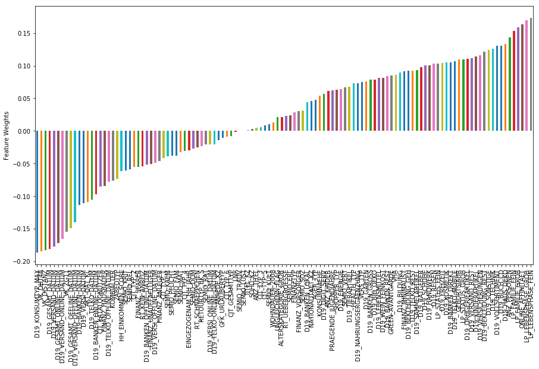

[figure not shown]

```python
# Map weights for the first principal component to corresponding feature names
# and then print the linked values, sorted by weight.
pca_results(azdias_final, azdias_pca_115, component_number = 1)
```

|  | Explained Variance | LNR | AGER_TYP | AKT_DAT_KL | ANZ_KINDER | ANZ_PERSONEN | ANZ_TITEL | CJT_GESAMTTYP | CJT_KATALOGNUTZER | CJT_TYP_1 | ... | UNGLEICHENN_FLAG | VERS_TYP | VHA | VK_DHT4A | VK_DISTANZ | VK_ZG11 | WOHNDAUER_2008 | ZABEOTYP | ANREDE_KZ | ALTERSKATEGORIE_GROB |
| --- | --- | --- | --- | --- | --- | --- | --- | --- | --- | --- | --- | --- | --- | --- | --- | --- | --- | --- | --- | --- | --- |
| Dimension 1 | 0.1430 | -0.0012 | 0.0480 | -0.1096 | 0.0616 | 0.1434 | 0.0050 | -0.0079 | -0.0858 | -0.0416 | ... | 0.0214 | 0.0753 | 0.0856 | -0.1852 | -0.1835 | -0.1552 | 0.0125 | -0.0735 | -0.0142 | 0.0216 |
| Dimension 2 | 0.1163 | 0.0037 | -0.1489 | 0.0648 | 0.0618 | 0.0170 | -0.0087 | 0.1047 | -0.1372 | 0.2224 | ... | 0.0292 | -0.0066 | -0.0262 | -0.0503 | 0.0092 | 0.0638 | -0.0821 | 0.0826 | 0.0153 | -0.2002 |
| Dimension 3 | 0.0555 | -0.0095 | 0.0123 | 0.0122 | -0.0312 | -0.0214 | 0.0027 | -0.0250 | 0.1504 | -0.0839 | ... | -0.0053 | 0.0798 | -0.0287 | 0.0386 | 0.0078 | -0.0441 | 0.0016 | -0.0205 | -0.3461 | -0.0314 |
| Dimension 4 | 0.0485 | 0.0210 | -0.0611 | -0.0473 | 0.0404 | 0.1200 | 0.0122 | 0.1385 | 0.0844 | 0.0730 | ... | 0.0360 | -0.3141 | 0.0520 | -0.1005 | -0.1123 | -0.1128 | 0.0432 | -0.1334 | -0.0646 | -0.0525 |
| Dimension 5 | 0.0325 | -0.0378 | 0.0822 | -0.0942 | -0.0532 | -0.1592 | -0.0177 | 0.0468 | 0.1409 | -0.0123 | ... | -0.1234 | -0.0962 | 0.0058 | -0.0481 | -0.0500 | -0.0396 | -0.1888 | 0.0659 | -0.0384 | 0.0477 |
| Dimension 6 | 0.0252 | -0.0507 | 0.0722 | 0.0851 | 0.0001 | 0.2065 | 0.0071 | -0.0190 | 0.0723 | -0.0118 | ... | 0.1036 | -0.0376 | 0.0940 | -0.0015 | -0.0603 | -0.0925 | 0.1699 | 0.0819 | 0.0047 | -0.0137 |
| Dimension 7 | 0.0210 | -0.0005 | 0.0328 | 0.0013 | -0.0957 | -0.1500 | 0.0215 | -0.0002 | -0.0057 | 0.0325 | ... | -0.1683 | 0.0255 | 0.0912 | 0.0845 | 0.0383 | -0.0084 | 0.0746 | -0.0407 | 0.0221 | -0.0752 |
| Dimension 8 | 0.0178 | 0.0499 | -0.1183 | 0.0961 | -0.0296 | -0.0137 | -0.0367 | -0.0224 | 0.0043 | 0.0079 | ... | -0.0826 | 0.0046 | -0.0379 | 0.1443 | 0.1590 | 0.1510 | 0.0476 | -0.0262 | -0.0125 | 0.0501 |
| Dimension 9 | 0.0149 | -0.0107 | 0.2292 | -0.1049 | -0.1189 | -0.0423 | 0.0856 | -0.0334 | -0.0296 | -0.0779 | ... | -0.0800 | -0.0033 | 0.0538 | 0.0095 | -0.0247 | -0.0348 | 0.1412 | 0.0159 | 0.0892 | -0.2338 |
| Dimension 10 | 0.0137 | 0.0459 | -0.0391 | 0.0423 | -0.0244 | 0.0115 | 0.6712 | -0.0023 | 0.0043 | 0.0134 | ... | 0.0240 | 0.0123 | -0.0469 | 0.0042 | -0.0103 | -0.0117 | -0.0366 | -0.0383 | -0.0054 | 0.0315 |
| Dimension 11 | 0.0134 | -0.0032 | 0.0497 | 0.0212 | -0.0020 | 0.0103 | -0.0601 | -0.0818 | 0.0106 | -0.0516 | ... | -0.0211 | 0.0287 | -0.0752 | -0.0140 | -0.0006 | 0.0113 | -0.1179 | -0.0209 | 0.0278 | -0.0841 |
| Dimension 12 | 0.0128 | 0.0468 | 0.0217 | 0.0738 | 0.0678 | 0.0283 | 0.0542 | -0.0432 | -0.0078 | -0.1014 | ... | 0.1247 | -0.0200 | -0.1169 | 0.0302 | 0.0923 | 0.1351 | -0.2560 | 0.0490 | -0.0164 | -0.0626 |
| Dimension 13 | 0.0119 | -0.3555 | -0.0446 | -0.1034 | 0.1732 | -0.0490 | 0.1301 | 0.0971 | -0.0921 | 0.0283 | ... | 0.0191 | -0.0545 | 0.1481 | -0.0835 | -0.0802 | -0.0657 | -0.0215 | 0.2112 | -0.0595 | 0.0663 |
| Dimension 14 | 0.0115 | -0.1088 | -0.1410 | 0.0794 | -0.0425 | 0.0178 | -0.0010 | 0.0658 | -0.0553 | 0.0126 | ... | -0.0610 | 0.0129 | 0.0088 | 0.0403 | 0.0491 | 0.0326 | 0.2532 | 0.0061 | -0.0450 | 0.0362 |
| Dimension 15 | 0.0111 | 0.2345 | -0.0660 | -0.0414 | 0.1049 | -0.0043 | -0.0085 | 0.1354 | -0.0563 | 0.0255 | ... | -0.0956 | -0.0550 | -0.1017 | 0.0909 | 0.1465 | 0.1486 | 0.3540 | 0.0734 | -0.0531 | 0.0647 |
| Dimension 16 | 0.0105 | -0.1773 | -0.0574 | 0.0350 | -0.0531 | 0.0119 | 0.1004 | -0.1195 | 0.0864 | -0.0683 | ... | -0.1727 | 0.0490 | -0.0377 | 0.0905 | 0.1100 | 0.0978 | 0.1955 | -0.0634 | 0.0619 | -0.0768 |
| Dimension 17 | 0.0102 | 0.2741 | 0.0235 | -0.0559 | 0.1320 | -0.0185 | 0.0198 | -0.0014 | -0.0246 | 0.0105 | ... | 0.0052 | -0.0683 | -0.0978 | 0.0566 | 0.0833 | 0.0986 | -0.0010 | 0.0164 | -0.0078 | 0.0591 |
| Dimension 18 | 0.0101 | -0.1843 | -0.0288 | -0.0508 | -0.2604 | 0.0422 | -0.0238 | 0.0751 | 0.0114 | 0.0655 | ... | -0.0683 | 0.0203 | 0.0229 | -0.0682 | -0.0838 | -0.1066 | -0.0178 | -0.0027 | -0.0119 | -0.0008 |
| Dimension 19 | 0.0092 | 0.1304 | -0.0441 | 0.0145 | -0.2325 | 0.0407 | 0.0001 | 0.0184 | 0.0014 | 0.0174 | ... | 0.0107 | -0.0225 | -0.1673 | 0.0101 | 0.0568 | 0.0640 | -0.1135 | -0.0564 | -0.0116 | 0.0242 |
| Dimension 20 | 0.0089 | -0.4157 | -0.1664 | 0.1409 | -0.0722 | 0.0348 | -0.0395 | 0.0157 | 0.0156 | -0.0297 | ... | 0.0109 | 0.0688 | -0.1423 | -0.0093 | -0.0417 | -0.0652 | -0.0673 | -0.2199 | 0.0001 | -0.0778 |
| Dimension 21 | 0.0086 | 0.1957 | -0.0838 | 0.1139 | -0.0095 | 0.0113 | -0.0043 | 0.0428 | -0.0653 | -0.0320 | ... | 0.0038 | 0.0453 | 0.2553 | -0.0195 | -0.0309 | -0.0222 | -0.0475 | -0.1450 | -0.0216 | -0.0159 |
| Dimension 22 | 0.0085 | -0.2805 | 0.0340 | -0.0044 | -0.0210 | -0.0614 | -0.0137 | -0.1598 | -0.0073 | 0.0094 | ... | -0.0469 | -0.1469 | -0.2095 | 0.0948 | 0.0963 | 0.0689 | 0.0042 | 0.0075 | 0.0649 | 0.0840 |
| Dimension 23 | 0.0085 | 0.0367 | -0.0410 | 0.0349 | -0.0391 | 0.0118 | 0.0027 | 0.0102 | -0.0069 | -0.0076 | ... | 0.0427 | 0.0026 | 0.0424 | 0.0078 | 0.0174 | 0.0231 | -0.0361 | -0.0568 | -0.0024 | 0.0011 |
| Dimension 24 | 0.0084 | -0.0488 | 0.1388 | -0.1286 | 0.1827 | -0.0096 | 0.0057 | 0.0717 | 0.0348 | 0.0335 | ... | 0.0371 | 0.0591 | -0.0920 | -0.0492 | -0.0672 | -0.0739 | 0.1300 | 0.1207 | -0.0117 | -0.0403 |
| Dimension 25 | 0.0082 | 0.1355 | 0.0181 | -0.0534 | -0.0117 | 0.0365 | 0.0130 | 0.0781 | 0.0176 | 0.0161 | ... | 0.1756 | 0.0381 | 0.0827 | -0.0294 | -0.0246 | -0.0088 | -0.0467 | 0.0829 | -0.0298 | -0.0072 |
| Dimension 26 | 0.0081 | -0.0290 | 0.1796 | -0.0561 | 0.0345 | -0.0043 | -0.0034 | 0.0592 | 0.0089 | 0.0349 | ... | 0.0218 | -0.0259 | 0.0513 | -0.0207 | -0.0266 | -0.0282 | 0.0659 | 0.1299 | 0.0109 | 0.0192 |
| Dimension 27 | 0.0078 | -0.0734 | -0.0014 | 0.0427 | 0.0039 | 0.0439 | -0.0020 | 0.0353 | 0.0308 | 0.0231 | ... | 0.3949 | -0.0200 | -0.0251 | 0.0611 | 0.0729 | 0.0723 | -0.0108 | -0.0237 | 0.0334 | 0.0221 |
| Dimension 28 | 0.0078 | 0.1298 | -0.0432 | -0.0352 | 0.0253 | 0.0016 | 0.0160 | 0.0289 | -0.0044 | -0.0265 | ... | 0.0626 | 0.0632 | -0.0834 | -0.0411 | -0.0284 | -0.0139 | -0.0304 | 0.0583 | -0.0333 | -0.0656 |
| Dimension 29 | 0.0077 | -0.0499 | -0.0538 | 0.0532 | 0.0062 | -0.0107 | -0.0057 | -0.0157 | -0.0164 | -0.0220 | ... | -0.0983 | -0.0159 | 0.1730 | 0.0152 | 0.0116 | 0.0132 | -0.0414 | -0.0307 | 0.0192 | 0.0188 |
| Dimension 30 | 0.0077 | 0.0400 | -0.1839 | -0.0331 | -0.0540 | -0.0223 | 0.0023 | -0.1965 | -0.0395 | -0.0548 | ... | -0.0693 | -0.0630 | -0.0422 | 0.0051 | 0.0018 | 0.0194 | -0.1439 | 0.0446 | -0.0055 | 0.0871 |

[output cut: 85 more lines]

115 rows × 119 columns

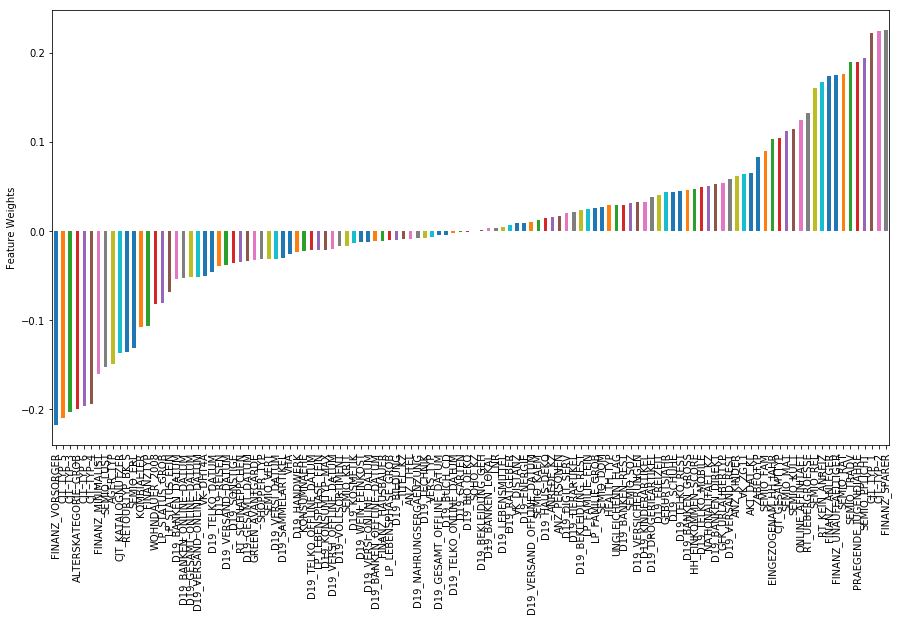

[figure not shown]

```python
# Map weights for the second principal component to corresponding feature names
# and then print the linked values, sorted by weight.
pca_results(azdias_final, azdias_pca_115, component_number = 2)
```

|  | Explained Variance | LNR | AGER_TYP | AKT_DAT_KL | ANZ_KINDER | ANZ_PERSONEN | ANZ_TITEL | CJT_GESAMTTYP | CJT_KATALOGNUTZER | CJT_TYP_1 | ... | UNGLEICHENN_FLAG | VERS_TYP | VHA | VK_DHT4A | VK_DISTANZ | VK_ZG11 | WOHNDAUER_2008 | ZABEOTYP | ANREDE_KZ | ALTERSKATEGORIE_GROB |
| --- | --- | --- | --- | --- | --- | --- | --- | --- | --- | --- | --- | --- | --- | --- | --- | --- | --- | --- | --- | --- | --- |
| Dimension 1 | 0.1430 | -0.0012 | 0.0480 | -0.1096 | 0.0616 | 0.1434 | 0.0050 | -0.0079 | -0.0858 | -0.0416 | ... | 0.0214 | 0.0753 | 0.0856 | -0.1852 | -0.1835 | -0.1552 | 0.0125 | -0.0735 | -0.0142 | 0.0216 |
| Dimension 2 | 0.1163 | 0.0037 | -0.1489 | 0.0648 | 0.0618 | 0.0170 | -0.0087 | 0.1047 | -0.1372 | 0.2224 | ... | 0.0292 | -0.0066 | -0.0262 | -0.0503 | 0.0092 | 0.0638 | -0.0821 | 0.0826 | 0.0153 | -0.2002 |
| Dimension 3 | 0.0555 | -0.0095 | 0.0123 | 0.0122 | -0.0312 | -0.0214 | 0.0027 | -0.0250 | 0.1504 | -0.0839 | ... | -0.0053 | 0.0798 | -0.0287 | 0.0386 | 0.0078 | -0.0441 | 0.0016 | -0.0205 | -0.3461 | -0.0314 |
| Dimension 4 | 0.0485 | 0.0210 | -0.0611 | -0.0473 | 0.0404 | 0.1200 | 0.0122 | 0.1385 | 0.0844 | 0.0730 | ... | 0.0360 | -0.3141 | 0.0520 | -0.1005 | -0.1123 | -0.1128 | 0.0432 | -0.1334 | -0.0646 | -0.0525 |
| Dimension 5 | 0.0325 | -0.0378 | 0.0822 | -0.0942 | -0.0532 | -0.1592 | -0.0177 | 0.0468 | 0.1409 | -0.0123 | ... | -0.1234 | -0.0962 | 0.0058 | -0.0481 | -0.0500 | -0.0396 | -0.1888 | 0.0659 | -0.0384 | 0.0477 |
| Dimension 6 | 0.0252 | -0.0507 | 0.0722 | 0.0851 | 0.0001 | 0.2065 | 0.0071 | -0.0190 | 0.0723 | -0.0118 | ... | 0.1036 | -0.0376 | 0.0940 | -0.0015 | -0.0603 | -0.0925 | 0.1699 | 0.0819 | 0.0047 | -0.0137 |
| Dimension 7 | 0.0210 | -0.0005 | 0.0328 | 0.0013 | -0.0957 | -0.1500 | 0.0215 | -0.0002 | -0.0057 | 0.0325 | ... | -0.1683 | 0.0255 | 0.0912 | 0.0845 | 0.0383 | -0.0084 | 0.0746 | -0.0407 | 0.0221 | -0.0752 |
| Dimension 8 | 0.0178 | 0.0499 | -0.1183 | 0.0961 | -0.0296 | -0.0137 | -0.0367 | -0.0224 | 0.0043 | 0.0079 | ... | -0.0826 | 0.0046 | -0.0379 | 0.1443 | 0.1590 | 0.1510 | 0.0476 | -0.0262 | -0.0125 | 0.0501 |
| Dimension 9 | 0.0149 | -0.0107 | 0.2292 | -0.1049 | -0.1189 | -0.0423 | 0.0856 | -0.0334 | -0.0296 | -0.0779 | ... | -0.0800 | -0.0033 | 0.0538 | 0.0095 | -0.0247 | -0.0348 | 0.1412 | 0.0159 | 0.0892 | -0.2338 |
| Dimension 10 | 0.0137 | 0.0459 | -0.0391 | 0.0423 | -0.0244 | 0.0115 | 0.6712 | -0.0023 | 0.0043 | 0.0134 | ... | 0.0240 | 0.0123 | -0.0469 | 0.0042 | -0.0103 | -0.0117 | -0.0366 | -0.0383 | -0.0054 | 0.0315 |
| Dimension 11 | 0.0134 | -0.0032 | 0.0497 | 0.0212 | -0.0020 | 0.0103 | -0.0601 | -0.0818 | 0.0106 | -0.0516 | ... | -0.0211 | 0.0287 | -0.0752 | -0.0140 | -0.0006 | 0.0113 | -0.1179 | -0.0209 | 0.0278 | -0.0841 |
| Dimension 12 | 0.0128 | 0.0468 | 0.0217 | 0.0738 | 0.0678 | 0.0283 | 0.0542 | -0.0432 | -0.0078 | -0.1014 | ... | 0.1247 | -0.0200 | -0.1169 | 0.0302 | 0.0923 | 0.1351 | -0.2560 | 0.0490 | -0.0164 | -0.0626 |
| Dimension 13 | 0.0119 | -0.3555 | -0.0446 | -0.1034 | 0.1732 | -0.0490 | 0.1301 | 0.0971 | -0.0921 | 0.0283 | ... | 0.0191 | -0.0545 | 0.1481 | -0.0835 | -0.0802 | -0.0657 | -0.0215 | 0.2112 | -0.0595 | 0.0663 |
| Dimension 14 | 0.0115 | -0.1088 | -0.1410 | 0.0794 | -0.0425 | 0.0178 | -0.0010 | 0.0658 | -0.0553 | 0.0126 | ... | -0.0610 | 0.0129 | 0.0088 | 0.0403 | 0.0491 | 0.0326 | 0.2532 | 0.0061 | -0.0450 | 0.0362 |
| Dimension 15 | 0.0111 | 0.2345 | -0.0660 | -0.0414 | 0.1049 | -0.0043 | -0.0085 | 0.1354 | -0.0563 | 0.0255 | ... | -0.0956 | -0.0550 | -0.1017 | 0.0909 | 0.1465 | 0.1486 | 0.3540 | 0.0734 | -0.0531 | 0.0647 |
| Dimension 16 | 0.0105 | -0.1773 | -0.0574 | 0.0350 | -0.0531 | 0.0119 | 0.1004 | -0.1195 | 0.0864 | -0.0683 | ... | -0.1727 | 0.0490 | -0.0377 | 0.0905 | 0.1100 | 0.0978 | 0.1955 | -0.0634 | 0.0619 | -0.0768 |
| Dimension 17 | 0.0102 | 0.2741 | 0.0235 | -0.0559 | 0.1320 | -0.0185 | 0.0198 | -0.0014 | -0.0246 | 0.0105 | ... | 0.0052 | -0.0683 | -0.0978 | 0.0566 | 0.0833 | 0.0986 | -0.0010 | 0.0164 | -0.0078 | 0.0591 |
| Dimension 18 | 0.0101 | -0.1843 | -0.0288 | -0.0508 | -0.2604 | 0.0422 | -0.0238 | 0.0751 | 0.0114 | 0.0655 | ... | -0.0683 | 0.0203 | 0.0229 | -0.0682 | -0.0838 | -0.1066 | -0.0178 | -0.0027 | -0.0119 | -0.0008 |
| Dimension 19 | 0.0092 | 0.1304 | -0.0441 | 0.0145 | -0.2325 | 0.0407 | 0.0001 | 0.0184 | 0.0014 | 0.0174 | ... | 0.0107 | -0.0225 | -0.1673 | 0.0101 | 0.0568 | 0.0640 | -0.1135 | -0.0564 | -0.0116 | 0.0242 |
| Dimension 20 | 0.0089 | -0.4157 | -0.1664 | 0.1409 | -0.0722 | 0.0348 | -0.0395 | 0.0157 | 0.0156 | -0.0297 | ... | 0.0109 | 0.0688 | -0.1423 | -0.0093 | -0.0417 | -0.0652 | -0.0673 | -0.2199 | 0.0001 | -0.0778 |
| Dimension 21 | 0.0086 | 0.1957 | -0.0838 | 0.1139 | -0.0095 | 0.0113 | -0.0043 | 0.0428 | -0.0653 | -0.0320 | ... | 0.0038 | 0.0453 | 0.2553 | -0.0195 | -0.0309 | -0.0222 | -0.0475 | -0.1450 | -0.0216 | -0.0159 |
| Dimension 22 | 0.0085 | -0.2805 | 0.0340 | -0.0044 | -0.0210 | -0.0614 | -0.0137 | -0.1598 | -0.0073 | 0.0094 | ... | -0.0469 | -0.1469 | -0.2095 | 0.0948 | 0.0963 | 0.0689 | 0.0042 | 0.0075 | 0.0649 | 0.0840 |
| Dimension 23 | 0.0085 | 0.0367 | -0.0410 | 0.0349 | -0.0391 | 0.0118 | 0.0027 | 0.0102 | -0.0069 | -0.0076 | ... | 0.0427 | 0.0026 | 0.0424 | 0.0078 | 0.0174 | 0.0231 | -0.0361 | -0.0568 | -0.0024 | 0.0011 |
| Dimension 24 | 0.0084 | -0.0488 | 0.1388 | -0.1286 | 0.1827 | -0.0096 | 0.0057 | 0.0717 | 0.0348 | 0.0335 | ... | 0.0371 | 0.0591 | -0.0920 | -0.0492 | -0.0672 | -0.0739 | 0.1300 | 0.1207 | -0.0117 | -0.0403 |
| Dimension 25 | 0.0082 | 0.1355 | 0.0181 | -0.0534 | -0.0117 | 0.0365 | 0.0130 | 0.0781 | 0.0176 | 0.0161 | ... | 0.1756 | 0.0381 | 0.0827 | -0.0294 | -0.0246 | -0.0088 | -0.0467 | 0.0829 | -0.0298 | -0.0072 |
| Dimension 26 | 0.0081 | -0.0290 | 0.1796 | -0.0561 | 0.0345 | -0.0043 | -0.0034 | 0.0592 | 0.0089 | 0.0349 | ... | 0.0218 | -0.0259 | 0.0513 | -0.0207 | -0.0266 | -0.0282 | 0.0659 | 0.1299 | 0.0109 | 0.0192 |
| Dimension 27 | 0.0078 | -0.0734 | -0.0014 | 0.0427 | 0.0039 | 0.0439 | -0.0020 | 0.0353 | 0.0308 | 0.0231 | ... | 0.3949 | -0.0200 | -0.0251 | 0.0611 | 0.0729 | 0.0723 | -0.0108 | -0.0237 | 0.0334 | 0.0221 |
| Dimension 28 | 0.0078 | 0.1298 | -0.0432 | -0.0352 | 0.0253 | 0.0016 | 0.0160 | 0.0289 | -0.0044 | -0.0265 | ... | 0.0626 | 0.0632 | -0.0834 | -0.0411 | -0.0284 | -0.0139 | -0.0304 | 0.0583 | -0.0333 | -0.0656 |
| Dimension 29 | 0.0077 | -0.0499 | -0.0538 | 0.0532 | 0.0062 | -0.0107 | -0.0057 | -0.0157 | -0.0164 | -0.0220 | ... | -0.0983 | -0.0159 | 0.1730 | 0.0152 | 0.0116 | 0.0132 | -0.0414 | -0.0307 | 0.0192 | 0.0188 |
| Dimension 30 | 0.0077 | 0.0400 | -0.1839 | -0.0331 | -0.0540 | -0.0223 | 0.0023 | -0.1965 | -0.0395 | -0.0548 | ... | -0.0693 | -0.0630 | -0.0422 | 0.0051 | 0.0018 | 0.0194 | -0.1439 | 0.0446 | -0.0055 | 0.0871 |

[output cut: 85 more lines]

115 rows × 119 columns

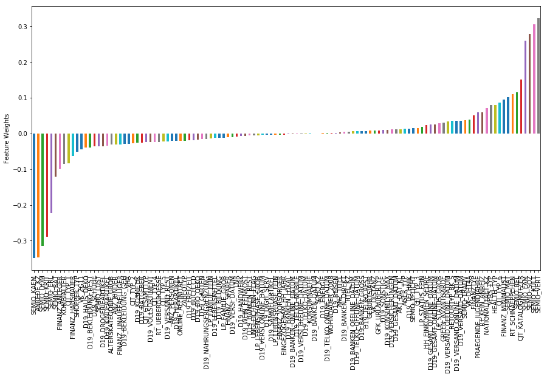

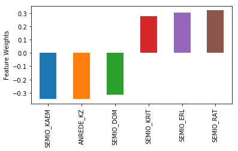

```python
# Map weights for the third principal component to corresponding feature names
# and then print the linked values, sorted by weight.
pca_results(azdias_final, azdias_pca_115, component_number = 3)
```

|  | Explained Variance | LNR | AGER_TYP | AKT_DAT_KL | ANZ_KINDER | ANZ_PERSONEN | ANZ_TITEL | CJT_GESAMTTYP | CJT_KATALOGNUTZER | CJT_TYP_1 | ... | UNGLEICHENN_FLAG | VERS_TYP | VHA | VK_DHT4A | VK_DISTANZ | VK_ZG11 | WOHNDAUER_2008 | ZABEOTYP | ANREDE_KZ | ALTERSKATEGORIE_GROB |
| --- | --- | --- | --- | --- | --- | --- | --- | --- | --- | --- | --- | --- | --- | --- | --- | --- | --- | --- | --- | --- | --- |
| Dimension 1 | 0.1430 | -0.0012 | 0.0480 | -0.1096 | 0.0616 | 0.1434 | 0.0050 | -0.0079 | -0.0858 | -0.0416 | ... | 0.0214 | 0.0753 | 0.0856 | -0.1852 | -0.1835 | -0.1552 | 0.0125 | -0.0735 | -0.0142 | 0.0216 |
| Dimension 2 | 0.1163 | 0.0037 | -0.1489 | 0.0648 | 0.0618 | 0.0170 | -0.0087 | 0.1047 | -0.1372 | 0.2224 | ... | 0.0292 | -0.0066 | -0.0262 | -0.0503 | 0.0092 | 0.0638 | -0.0821 | 0.0826 | 0.0153 | -0.2002 |
| Dimension 3 | 0.0555 | -0.0095 | 0.0123 | 0.0122 | -0.0312 | -0.0214 | 0.0027 | -0.0250 | 0.1504 | -0.0839 | ... | -0.0053 | 0.0798 | -0.0287 | 0.0386 | 0.0078 | -0.0441 | 0.0016 | -0.0205 | -0.3461 | -0.0314 |
| Dimension 4 | 0.0485 | 0.0210 | -0.0611 | -0.0473 | 0.0404 | 0.1200 | 0.0122 | 0.1385 | 0.0844 | 0.0730 | ... | 0.0360 | -0.3141 | 0.0520 | -0.1005 | -0.1123 | -0.1128 | 0.0432 | -0.1334 | -0.0646 | -0.0525 |
| Dimension 5 | 0.0325 | -0.0378 | 0.0822 | -0.0942 | -0.0532 | -0.1592 | -0.0177 | 0.0468 | 0.1409 | -0.0123 | ... | -0.1234 | -0.0962 | 0.0058 | -0.0481 | -0.0500 | -0.0396 | -0.1888 | 0.0659 | -0.0384 | 0.0477 |
| Dimension 6 | 0.0252 | -0.0507 | 0.0722 | 0.0851 | 0.0001 | 0.2065 | 0.0071 | -0.0190 | 0.0723 | -0.0118 | ... | 0.1036 | -0.0376 | 0.0940 | -0.0015 | -0.0603 | -0.0925 | 0.1699 | 0.0819 | 0.0047 | -0.0137 |
| Dimension 7 | 0.0210 | -0.0005 | 0.0328 | 0.0013 | -0.0957 | -0.1500 | 0.0215 | -0.0002 | -0.0057 | 0.0325 | ... | -0.1683 | 0.0255 | 0.0912 | 0.0845 | 0.0383 | -0.0084 | 0.0746 | -0.0407 | 0.0221 | -0.0752 |
| Dimension 8 | 0.0178 | 0.0499 | -0.1183 | 0.0961 | -0.0296 | -0.0137 | -0.0367 | -0.0224 | 0.0043 | 0.0079 | ... | -0.0826 | 0.0046 | -0.0379 | 0.1443 | 0.1590 | 0.1510 | 0.0476 | -0.0262 | -0.0125 | 0.0501 |
| Dimension 9 | 0.0149 | -0.0107 | 0.2292 | -0.1049 | -0.1189 | -0.0423 | 0.0856 | -0.0334 | -0.0296 | -0.0779 | ... | -0.0800 | -0.0033 | 0.0538 | 0.0095 | -0.0247 | -0.0348 | 0.1412 | 0.0159 | 0.0892 | -0.2338 |
| Dimension 10 | 0.0137 | 0.0459 | -0.0391 | 0.0423 | -0.0244 | 0.0115 | 0.6712 | -0.0023 | 0.0043 | 0.0134 | ... | 0.0240 | 0.0123 | -0.0469 | 0.0042 | -0.0103 | -0.0117 | -0.0366 | -0.0383 | -0.0054 | 0.0315 |
| Dimension 11 | 0.0134 | -0.0032 | 0.0497 | 0.0212 | -0.0020 | 0.0103 | -0.0601 | -0.0818 | 0.0106 | -0.0516 | ... | -0.0211 | 0.0287 | -0.0752 | -0.0140 | -0.0006 | 0.0113 | -0.1179 | -0.0209 | 0.0278 | -0.0841 |
| Dimension 12 | 0.0128 | 0.0468 | 0.0217 | 0.0738 | 0.0678 | 0.0283 | 0.0542 | -0.0432 | -0.0078 | -0.1014 | ... | 0.1247 | -0.0200 | -0.1169 | 0.0302 | 0.0923 | 0.1351 | -0.2560 | 0.0490 | -0.0164 | -0.0626 |
| Dimension 13 | 0.0119 | -0.3555 | -0.0446 | -0.1034 | 0.1732 | -0.0490 | 0.1301 | 0.0971 | -0.0921 | 0.0283 | ... | 0.0191 | -0.0545 | 0.1481 | -0.0835 | -0.0802 | -0.0657 | -0.0215 | 0.2112 | -0.0595 | 0.0663 |
| Dimension 14 | 0.0115 | -0.1088 | -0.1410 | 0.0794 | -0.0425 | 0.0178 | -0.0010 | 0.0658 | -0.0553 | 0.0126 | ... | -0.0610 | 0.0129 | 0.0088 | 0.0403 | 0.0491 | 0.0326 | 0.2532 | 0.0061 | -0.0450 | 0.0362 |
| Dimension 15 | 0.0111 | 0.2345 | -0.0660 | -0.0414 | 0.1049 | -0.0043 | -0.0085 | 0.1354 | -0.0563 | 0.0255 | ... | -0.0956 | -0.0550 | -0.1017 | 0.0909 | 0.1465 | 0.1486 | 0.3540 | 0.0734 | -0.0531 | 0.0647 |
| Dimension 16 | 0.0105 | -0.1773 | -0.0574 | 0.0350 | -0.0531 | 0.0119 | 0.1004 | -0.1195 | 0.0864 | -0.0683 | ... | -0.1727 | 0.0490 | -0.0377 | 0.0905 | 0.1100 | 0.0978 | 0.1955 | -0.0634 | 0.0619 | -0.0768 |
| Dimension 17 | 0.0102 | 0.2741 | 0.0235 | -0.0559 | 0.1320 | -0.0185 | 0.0198 | -0.0014 | -0.0246 | 0.0105 | ... | 0.0052 | -0.0683 | -0.0978 | 0.0566 | 0.0833 | 0.0986 | -0.0010 | 0.0164 | -0.0078 | 0.0591 |
| Dimension 18 | 0.0101 | -0.1843 | -0.0288 | -0.0508 | -0.2604 | 0.0422 | -0.0238 | 0.0751 | 0.0114 | 0.0655 | ... | -0.0683 | 0.0203 | 0.0229 | -0.0682 | -0.0838 | -0.1066 | -0.0178 | -0.0027 | -0.0119 | -0.0008 |
| Dimension 19 | 0.0092 | 0.1304 | -0.0441 | 0.0145 | -0.2325 | 0.0407 | 0.0001 | 0.0184 | 0.0014 | 0.0174 | ... | 0.0107 | -0.0225 | -0.1673 | 0.0101 | 0.0568 | 0.0640 | -0.1135 | -0.0564 | -0.0116 | 0.0242 |
| Dimension 20 | 0.0089 | -0.4157 | -0.1664 | 0.1409 | -0.0722 | 0.0348 | -0.0395 | 0.0157 | 0.0156 | -0.0297 | ... | 0.0109 | 0.0688 | -0.1423 | -0.0093 | -0.0417 | -0.0652 | -0.0673 | -0.2199 | 0.0001 | -0.0778 |
| Dimension 21 | 0.0086 | 0.1957 | -0.0838 | 0.1139 | -0.0095 | 0.0113 | -0.0043 | 0.0428 | -0.0653 | -0.0320 | ... | 0.0038 | 0.0453 | 0.2553 | -0.0195 | -0.0309 | -0.0222 | -0.0475 | -0.1450 | -0.0216 | -0.0159 |
| Dimension 22 | 0.0085 | -0.2805 | 0.0340 | -0.0044 | -0.0210 | -0.0614 | -0.0137 | -0.1598 | -0.0073 | 0.0094 | ... | -0.0469 | -0.1469 | -0.2095 | 0.0948 | 0.0963 | 0.0689 | 0.0042 | 0.0075 | 0.0649 | 0.0840 |
| Dimension 23 | 0.0085 | 0.0367 | -0.0410 | 0.0349 | -0.0391 | 0.0118 | 0.0027 | 0.0102 | -0.0069 | -0.0076 | ... | 0.0427 | 0.0026 | 0.0424 | 0.0078 | 0.0174 | 0.0231 | -0.0361 | -0.0568 | -0.0024 | 0.0011 |
| Dimension 24 | 0.0084 | -0.0488 | 0.1388 | -0.1286 | 0.1827 | -0.0096 | 0.0057 | 0.0717 | 0.0348 | 0.0335 | ... | 0.0371 | 0.0591 | -0.0920 | -0.0492 | -0.0672 | -0.0739 | 0.1300 | 0.1207 | -0.0117 | -0.0403 |
| Dimension 25 | 0.0082 | 0.1355 | 0.0181 | -0.0534 | -0.0117 | 0.0365 | 0.0130 | 0.0781 | 0.0176 | 0.0161 | ... | 0.1756 | 0.0381 | 0.0827 | -0.0294 | -0.0246 | -0.0088 | -0.0467 | 0.0829 | -0.0298 | -0.0072 |
| Dimension 26 | 0.0081 | -0.0290 | 0.1796 | -0.0561 | 0.0345 | -0.0043 | -0.0034 | 0.0592 | 0.0089 | 0.0349 | ... | 0.0218 | -0.0259 | 0.0513 | -0.0207 | -0.0266 | -0.0282 | 0.0659 | 0.1299 | 0.0109 | 0.0192 |
| Dimension 27 | 0.0078 | -0.0734 | -0.0014 | 0.0427 | 0.0039 | 0.0439 | -0.0020 | 0.0353 | 0.0308 | 0.0231 | ... | 0.3949 | -0.0200 | -0.0251 | 0.0611 | 0.0729 | 0.0723 | -0.0108 | -0.0237 | 0.0334 | 0.0221 |
| Dimension 28 | 0.0078 | 0.1298 | -0.0432 | -0.0352 | 0.0253 | 0.0016 | 0.0160 | 0.0289 | -0.0044 | -0.0265 | ... | 0.0626 | 0.0632 | -0.0834 | -0.0411 | -0.0284 | -0.0139 | -0.0304 | 0.0583 | -0.0333 | -0.0656 |
| Dimension 29 | 0.0077 | -0.0499 | -0.0538 | 0.0532 | 0.0062 | -0.0107 | -0.0057 | -0.0157 | -0.0164 | -0.0220 | ... | -0.0983 | -0.0159 | 0.1730 | 0.0152 | 0.0116 | 0.0132 | -0.0414 | -0.0307 | 0.0192 | 0.0188 |
| Dimension 30 | 0.0077 | 0.0400 | -0.1839 | -0.0331 | -0.0540 | -0.0223 | 0.0023 | -0.1965 | -0.0395 | -0.0548 | ... | -0.0693 | -0.0630 | -0.0422 | 0.0051 | 0.0018 | 0.0194 | -0.1439 | 0.0446 | -0.0055 | 0.0871 |

[output cut: 85 more lines]

115 rows × 119 columns

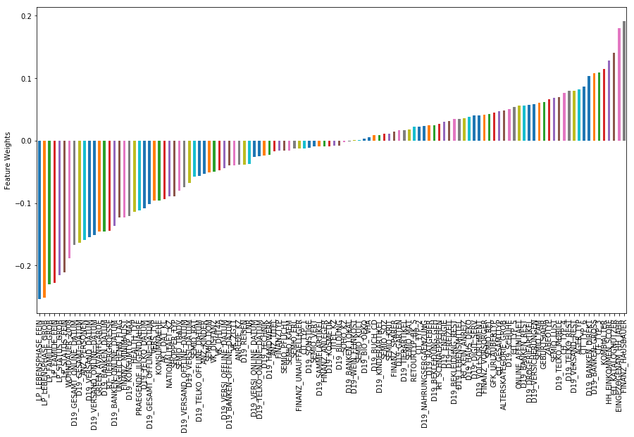

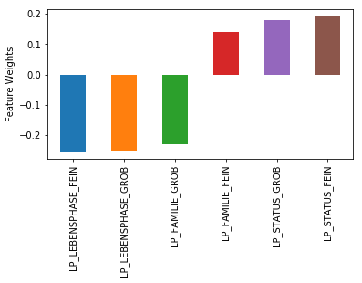

```python
# Map weights for the fifth principal component to corresponding feature names
# and then print the linked values, sorted by weight.
pca_results(azdias_final, azdias_pca_115, component_number = 5)
```

**Interpreting the PCA variables**

**Component #1**

```
**Weight Descriptoion** #1negative - **Attribute** -D19_KONSUMTYP_MAX - **Variable Meaning** - consumption type
**Weight Descriptoion** #2negative - **Attribute** -VK_DHT4A - **Variable Meaning** - Not known
**Weight Descriptoion** #3negative - **Attribute** -VK_DISTANZ - **Variable Meaning** - Not known
**Weight Descriptoion** #1positive - **Attribute** -D19_GESAMT_DATUM - **Variable Meaning** - actuality of the last transaction with the complete file TOTAL
**Weight Descriptoion** #2positive - **Attribute** -D19_VERSAND_DATUM - **Variable Meaning** - actuality of the last transaction for the segment mail-order TOTAL
**Weight Descriptoion** #3positive - **Attribute** -D19_GESAMT_ONLINE_DATUM - **Variable Meaning** - actuality of the last transaction with the complete file ONLINE
```

**Component #2**

```
**Weight Descriptoion** #1negative - **Attribute** -FINANZ_VORSORGER - **Variable Meaning** - financial typology: be prepared
**Weight Descriptoion** #2negative - **Attribute** -CJT_TYP_5 - **Variable Meaning** - Not known
**Weight Descriptoion** #3negative - **Attribute** -CJT_TYP_3 - **Variable Meaning** - Not known
**Weight Descriptoion** #1positive - **Attribute** -ALTERSKATEGORIE_GROB - **Variable Meaning** - age through prename analysis
**Weight Descriptoion** #2positive - **Attribute** -CJT_TYP_6 - **Variable Meaning** - Not known
**Weight Descriptoion** #3positive - **Attribute** -CJT_TYP_4 - **Variable Meaning** - Not known
```

**Component #3**

```
**Weight Descriptoion** #1negative - **Attribute** -SEMIO_KAEM - **Variable Meaning** - affinity indicating in what way the person is of a fightfull attitude
**Weight Descriptoion** #2negative - **Attribute** -ANREDE_KZ - **Variable Meaning** - Gender
**Weight Descriptoion** #3negative - **Attribute** -SEMIO_DOM - **Variable Meaning** - affinity indicating in what way the person is dominant minded
**Weight Descriptoion** #1positive - **Attribute** -SEMIO_KRIT - **Variable Meaning** - affinity indicating in what way the person is critical minded
**Weight Descriptoion** #2positive - **Attribute** -SEMIO_ERL - **Variable Meaning** - affinity indicating in what way the person is eventful orientated
**Weight Descriptoion** #3positive - **Attribute** -SEMIO_RAT - **Variable Meaning** - affinity indicating in what way the person is of a rational mind
```

**Component #5**

```
**Weight Descriptoion** #1negative - **Attribute** -LP_LEBENSPHASE_FEIN - **Variable Meaning** - lifestage fine (income)
**Weight Descriptoion** #2negative - **Attribute** -LP_LEBENSPHASE_GROB - **Variable Meaning** - lifestage rough
**Weight Descriptoion** #3negative - **Attribute** -LP_FAMILIE_GROB - **Variable Meaning** - familytyp rough
**Weight Descriptoion** #1positive - **Attribute** -LP_FAMILIE_FEIN - **Variable Meaning** -familytyp fine
**Weight Descriptoion** #2positive - **Attribute** -LP_STATUS_GROB - **Variable Meaning** - social status rough
**Weight Descriptoion** #3positive - **Attribute** -LP_STATUS_FEIN - **Variable Meaning** - social status fine
```

**Perform K-Means Clustering**

- Use sklearn's KMeans class to perform k-means clustering on the PCA-transformed data.
- Then, compute the average difference from each point to its assigned cluster's center.
- Perform the above two steps for a number of different cluster counts. You can then see how the average distance decreases with an increasing number of clusters. However, each additional cluster provides a smaller net benefit. Use this fact to select a final number of clusters in which to group the data.
- Once you've selected a final number of clusters to use, re-fit a KMeans instance to perform the clustering operation

```python
# Over a number of different cluster counts...
# run k-means clustering on the data and...
# compute the average within-cluster distances.

def elbow_plot(data, start_K, end_K, step):
    '''
    Generate an elbow plot to find optimal number of clusters
    graphing K values from start_K to end_K every step value

    INPUT:
        data: Demographics DataFrame
        start_K: Inclusive starting value for cluster number
        end_K: Exclusive stopping value for cluster number
        step: Step value between start_K and end_K
    OUTPUT: Trimmed and cleaned demographics DataFrame
    '''
    score_list = []

    for i in range(start_K, end_K, step):
        print(i)
        start = time.time()
        kmeans = KMeans(i)
        model = kmeans.fit(data)
        score = model.score(data)
        score_list.append(abs(score))
        end = time.time()
        elapsed_time = end - start
        print(elapsed_time)

    plt.plot(range(start_K, end_K, step),
    score_list, linestyle='--', marker='o', color='b');
    plt.xlabel('# of clusters K');
    plt.ylabel('Sum of squared errors');
    plt.title('SSE vs. K');
    plt.savefig('elbow_plot.png')
```

```
1
26.962457180023193
3
121.52739024162292
5
201.46400785446167
7
205.10281682014465
9
325.80536127090454
11
344.33550453186035
13
546.0588047504425
15
572.01757979393
17
690.8283169269562
19
664.7199306488037
```

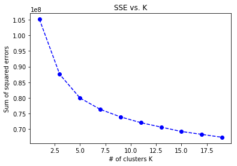

```python
# Investigate the change in within-cluster distance across number of clusters.

elbow_plot(azdias_X_pca_115, 1, 20, 2)
```

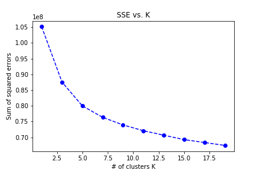

```python
# Have saved version of embow plot since it takes hours to generate
from IPython.display import Image
Image(filename='elbow_plot.png')
```

```python
# Fit the k-means model with the selected number of clusters and obtain
# cluster predictions for the general population demographics data (azdias).

azdias_kmeans = KMeans(8)
azdias_model = azdias_kmeans.fit(azdias_X_pca_115)
azdias_labels = azdias_model.predict(azdias_X_pca_115)
```

```python
# View first few labels predicted for the azdias dataset
azdias_labels[0:15]
```

```
array([1, 2, 2, 3, 7, 0, 2, 6, 0, 5, 3, 1, 5, 5, 1], dtype=int32)
```

```python
# Perform PCA on the customers dataset using the pca generated using azdias
customers_pca_115 = azdias_pca_115.transform(customers_final)
```

```python
# Perform clustering on customers dataset using model generated using azdias
customers_labels = azdias_model.predict(customers_pca_115)
```

```python
# View first few labels predicted for the customers dataset
customers_labels[0:15]
```

```
array([4, 3, 0, 7, 4, 4, 4, 3, 7, 7, 4, 4, 5, 3, 4], dtype=int32)
```

Comparing each cluster We have clustered data based on demographics of the general population of Germany, and see how it can map into the customer data. Now we can compare between clusters to see where is the strongest customer base.

```python
# Calculate the proportions of each cluster for the general population.
# Include the data that was initially removed due to too many NaNas when
# calculating the proportions and include this data as cluster -1.

general_pop = 891221

azdias_counter = Counter(azdias_labels)
azdias_proportions = [(i, azdias_counter[i] / general_pop * 100.0) for i in azdias_counter]
azdias_proportions.sort(key=itemgetter(0))
azdias_proportions = np.array(azdias_proportions)

dropped_gen_pop = 100 - azdias_proportions[:, 1].sum()

azdias_proportions = np.insert(azdias_proportions, 0, values=[-1, dropped_gen_pop], axis=0)
azdias_proportions
```

```
array([[ -1.00000000e+00,   1.42108547e-14],
       [  0.00000000e+00,   1.58110054e+01],
       [  1.00000000e+00,   1.07313450e+01],
       [  2.00000000e+00,   1.17545480e+01],
       [  3.00000000e+00,   1.53962934e+01],
       [  4.00000000e+00,   1.52769066e+01],
       [  5.00000000e+00,   1.36417342e+01],
       [  6.00000000e+00,   1.12504081e+01],
       [  7.00000000e+00,   6.13775932e+00]])
```

```python
# Calculate the proportions of each cluster for the customer population.
# Include the data that was initially removed due to too many NaNs when
# calculating the proportions and include this data as cluster -1.
cust_pop = 191652

customers_counter = Counter(customers_labels)
customers_proportions = [(i, customers_counter[i] / cust_pop * 100.0) for i in customers_counter]
customers_proportions.sort(key=itemgetter(0))
customers_proportions = np.array(customers_proportions)

dropped_cust_pop = 100 - customers_proportions[:, 1].sum()

customers_proportions = np.insert(customers_proportions, 0, values=[-1, dropped_cust_pop], axis=0)
customers_proportions
```

```
array([[ -1.        ,  25.98929309],
       [  0.        ,  12.07657629],
       [  1.        ,   0.19097114],
       [  2.        ,   0.62404775],
       [  3.        ,   9.06434579],
       [  4.        ,  38.42067915],
       [  5.        ,   3.64045249],
       [  6.        ,   0.99868512],
       [  7.        ,   8.99494918]])
```

```python
# Compare the proportion of data in each cluster for the customer data to the
# proportion of data in each cluster for the general population.
representation_ratio = customers_proportions[:, 1]/azdias_proportions[:, 1]
```

[figure not shown]

```python
# Plot the proportions for the general population, the customer population,
# and the ratio of customer/general populations.
plt.figure(figsize=(15, 4))

ax1 = plt.subplot(131)
ax1.bar(azdias_proportions[:, 0], azdias_proportions[:, 1])
ax1.set_xticks(azdias_proportions[:, 0])
ax1.set_ylim(ymax = 35)
ax1.set_xlabel("Cluster")
ax1.set_ylabel("Proportion of Total (%)")
plt.title('General Population')

ax2 = plt.subplot(132)
ax2.bar(customers_proportions[:, 0], customers_proportions[:, 1])
ax2.set_xticks(azdias_proportions[:, 0])
ax2.set_ylim(ymax = 35)
ax2.set_xlabel("Cluster")
ax2.set_ylabel("Proportion of Total (%)")
plt.title('Customer Population')

ax3 = plt.subplot(133)
ax3.bar(azdias_proportions[:, 0], representation_ratio)
ax3.set_xticks(azdias_proportions[:, 0])
ax3.set_xlabel("Cluster")
ax3.set_ylabel("Representation Ratio")
ax3.axhline(y=1, linestyle = "--", linewidth = 0.8)
plt.title('Customer Population/General Population')

plt.savefig('population_proportions.png');
```

## Part 2: Supervised Learning Model

Now that you've found which parts of the population are more likely to be customers of the mail-order company, it's time to build a prediction model. Each of the rows in the "MAILOUT" data files represents an individual that was targeted for a mailout campaign. Ideally, we should be able to use the demographic information from each individual to decide whether or not it will be worth it to include that person in the campaign.

The "MAILOUT" data has been split into two approximately equal parts, each with almost 43 000 data rows. In this part, you can verify your model with the "TRAIN" partition, which includes a column, "RESPONSE", that states whether or not a person became a customer of the company following the campaign. In the next part, you'll need to create predictions on the "TEST" partition, where the "RESPONSE" column has been withheld.

```python
#Understand the training mailout dataset

train_data.head()
```

|  | LNR | AGER_TYP | AKT_DAT_KL | ALTER_HH | ALTER_KIND1 | ALTER_KIND2 | ALTER_KIND3 | ALTER_KIND4 | ALTERSKATEGORIE_FEIN | ANZ_HAUSHALTE_AKTIV | ... | VK_DHT4A | VK_DISTANZ | VK_ZG11 | W_KEIT_KIND_HH | WOHNDAUER_2008 | WOHNLAGE | ZABEOTYP | RESPONSE | ANREDE_KZ | ALTERSKATEGORIE_GROB |
| --- | --- | --- | --- | --- | --- | --- | --- | --- | --- | --- | --- | --- | --- | --- | --- | --- | --- | --- | --- | --- | --- |
| 0 | 1763 | 2 | 1.0 | 8.0 | NaN | NaN | NaN | NaN | 8.0 | 15.0 | ... | 5.0 | 2.0 | 1.0 | 6.0 | 9.0 | 3.0 | 3 | 0 | 2 | 4 |
| 1 | 1771 | 1 | 4.0 | 13.0 | NaN | NaN | NaN | NaN | 13.0 | 1.0 | ... | 1.0 | 2.0 | 1.0 | 4.0 | 9.0 | 7.0 | 1 | 0 | 2 | 3 |
| 2 | 1776 | 1 | 1.0 | 9.0 | NaN | NaN | NaN | NaN | 7.0 | 0.0 | ... | 6.0 | 4.0 | 2.0 | NaN | 9.0 | 2.0 | 3 | 0 | 1 | 4 |
| 3 | 1460 | 2 | 1.0 | 6.0 | NaN | NaN | NaN | NaN | 6.0 | 4.0 | ... | 8.0 | 11.0 | 11.0 | 6.0 | 9.0 | 1.0 | 3 | 0 | 2 | 4 |
| 4 | 1783 | 2 | 1.0 | 9.0 | NaN | NaN | NaN | NaN | 9.0 | 53.0 | ... | 2.0 | 2.0 | 1.0 | 6.0 | 9.0 | 3.0 | 3 | 0 | 1 | 3 |

5 rows × 367 columns

```python
# Clean the training data (may need to rerun cell with cleaning function, loading unknowns.pickle)
train_data = clean_data(train_data, unknowns, cols_to_drop_test)
train_data.head()
```

|  | LNR | AGER_TYP | AKT_DAT_KL | ANZ_KINDER | ANZ_PERSONEN | ANZ_TITEL | CJT_KATALOGNUTZER | CJT_TYP_1 | CJT_TYP_2 | CJT_TYP_3 | ... | UNGLEICHENN_FLAG | VHA | VK_DHT4A | VK_DISTANZ | VK_ZG11 | WOHNDAUER_2008 | ZABEOTYP | RESPONSE | ANREDE_KZ | ALTERSKATEGORIE_GROB |
| --- | --- | --- | --- | --- | --- | --- | --- | --- | --- | --- | --- | --- | --- | --- | --- | --- | --- | --- | --- | --- | --- |
| 0 | 1763.0 | 2.0 | 1.0 | 0.0 | 1.0 | 0.0 | 5.0 | 2.0 | 2.0 | 5.0 | ... | 0.0 | 1.0 | 5.0 | 2.0 | 1.0 | 9.0 | 3.0 | 0.0 | 2.0 | 4.0 |
| 1 | 1771.0 | 1.0 | 4.0 | 0.0 | 2.0 | 0.0 | 2.0 | 2.0 | 2.0 | 4.0 | ... | 0.0 | 1.0 | 1.0 | 2.0 | 1.0 | 9.0 | 1.0 | 0.0 | 2.0 | 3.0 |
| 2 | 1776.0 | 1.0 | 1.0 | 0.0 | 0.0 | 0.0 | 5.0 | 1.0 | 1.0 | 5.0 | ... | 0.0 | 4.0 | 6.0 | 4.0 | 2.0 | 9.0 | 3.0 | 0.0 | 1.0 | 4.0 |
| 3 | 1460.0 | 2.0 | 1.0 | 0.0 | 2.0 | 0.0 | 5.0 | 2.0 | 2.0 | 5.0 | ... | 0.0 | 1.0 | 8.0 | 11.0 | 11.0 | 9.0 | 3.0 | 0.0 | 2.0 | 4.0 |
| 4 | 1783.0 | 2.0 | 1.0 | 0.0 | 1.0 | 0.0 | 5.0 | 1.0 | 2.0 | 5.0 | ... | 0.0 | 0.0 | 2.0 | 2.0 | 1.0 | 9.0 | 3.0 | 0.0 | 1.0 | 3.0 |

5 rows × 111 columns

```python
# Define the labels (y) to be the response column, and the rest of the columns to be X
y = train_data['RESPONSE']
del train_data['RESPONSE']
X = train_data
y.shape, X.shape
```

```
((35388,), (35388, 110))
```

```python
# Obtain the vale counts for the response column
y.value_counts()
```

```
0.0    34944
1.0      444
Name: RESPONSE, dtype: int64
```

```python
# Print first few responses to ensre they are in an expected form
y.head()
```

```
0    0.0
1    0.0
2    0.0
3    0.0
4    0.0
Name: RESPONSE, dtype: float64
```

```python
#Perform imputer
# Perform imputation on train df
imputer = Imputer()
X = pd.DataFrame(imputer.fit_transform(X), columns = X.columns)
X.head()
```

|  | LNR | AGER_TYP | AKT_DAT_KL | ANZ_KINDER | ANZ_PERSONEN | ANZ_TITEL | CJT_KATALOGNUTZER | CJT_TYP_1 | CJT_TYP_2 | CJT_TYP_3 | ... | TITEL_KZ | UNGLEICHENN_FLAG | VHA | VK_DHT4A | VK_DISTANZ | VK_ZG11 | WOHNDAUER_2008 | ZABEOTYP | ANREDE_KZ | ALTERSKATEGORIE_GROB |
| --- | --- | --- | --- | --- | --- | --- | --- | --- | --- | --- | --- | --- | --- | --- | --- | --- | --- | --- | --- | --- | --- |
| 0 | 1763.0 | 2.0 | 1.0 | 0.0 | 1.0 | 0.0 | 5.0 | 2.0 | 2.0 | 5.0 | ... | 0.0 | 0.0 | 1.0 | 5.0 | 2.0 | 1.0 | 9.0 | 3.0 | 2.0 | 4.0 |
| 1 | 1771.0 | 1.0 | 4.0 | 0.0 | 2.0 | 0.0 | 2.0 | 2.0 | 2.0 | 4.0 | ... | 0.0 | 0.0 | 1.0 | 1.0 | 2.0 | 1.0 | 9.0 | 1.0 | 2.0 | 3.0 |
| 2 | 1776.0 | 1.0 | 1.0 | 0.0 | 0.0 | 0.0 | 5.0 | 1.0 | 1.0 | 5.0 | ... | 0.0 | 0.0 | 4.0 | 6.0 | 4.0 | 2.0 | 9.0 | 3.0 | 1.0 | 4.0 |
| 3 | 1460.0 | 2.0 | 1.0 | 0.0 | 2.0 | 0.0 | 5.0 | 2.0 | 2.0 | 5.0 | ... | 0.0 | 0.0 | 1.0 | 8.0 | 11.0 | 11.0 | 9.0 | 3.0 | 2.0 | 4.0 |
| 4 | 1783.0 | 2.0 | 1.0 | 0.0 | 1.0 | 0.0 | 5.0 | 1.0 | 2.0 | 5.0 | ... | 0.0 | 0.0 | 0.0 | 2.0 | 2.0 | 1.0 | 9.0 | 3.0 | 1.0 | 3.0 |

5 rows × 110 columns

```python
# Apply feature scaling to the train df
scaler = StandardScaler()
X = pd.DataFrame(scaler.fit_transform(X), columns = X.columns)
X.head()
```

|  | LNR | AGER_TYP | AKT_DAT_KL | ANZ_KINDER | ANZ_PERSONEN | ANZ_TITEL | CJT_KATALOGNUTZER | CJT_TYP_1 | CJT_TYP_2 | CJT_TYP_3 | ... | TITEL_KZ | UNGLEICHENN_FLAG | VHA | VK_DHT4A | VK_DISTANZ | VK_ZG11 | WOHNDAUER_2008 | ZABEOTYP | ANREDE_KZ | ALTERSKATEGORIE_GROB |
| --- | --- | --- | --- | --- | --- | --- | --- | --- | --- | --- | --- | --- | --- | --- | --- | --- | --- | --- | --- | --- | --- |
| 0 | -1.659439 | 0.855179 | -0.294108 | -0.224948 | -0.747912 | -0.091977 | 0.860440 | -0.148692 | 0.118222 | 0.624299 | ... | -0.061896 | -0.276184 | -0.089596 | 0.214153 | -0.762048 | -0.835357 | 0.268232 | 0.192385 | 0.852002 | 0.587754 |
| 1 | -1.659116 | 0.115829 | 1.476846 | -0.224948 | -0.011569 | -0.091977 | -1.171903 | -0.148692 | 0.118222 | -0.407877 | ... | -0.061896 | -0.276184 | -0.089596 | -1.048817 | -0.762048 | -0.835357 | 0.268232 | -1.444578 | 0.852002 | -0.646634 |
| 2 | -1.658915 | 0.115829 | -0.294108 | -0.224948 | -1.484256 | -0.091977 | 0.860440 | -1.140195 | -0.916821 | 0.624299 | ... | -0.061896 | -0.276184 | 1.839798 | 0.529896 | -0.154258 | -0.440760 | 0.268232 | 0.192385 | -1.173706 | 0.587754 |
| 3 | -1.671646 | 0.855179 | -0.294108 | -0.224948 | -0.011569 | -0.091977 | 0.860440 | -0.148692 | 0.118222 | 0.624299 | ... | -0.061896 | -0.276184 | -0.089596 | 1.161381 | 1.973009 | 3.110610 | 0.268232 | 0.192385 | 0.852002 | 0.587754 |
| 4 | -1.658633 | 0.855179 | -0.294108 | -0.224948 | -0.747912 | -0.091977 | 0.860440 | -1.140195 | 0.118222 | 0.624299 | ... | -0.061896 | -0.276184 | -0.732728 | -0.733074 | -0.762048 | -0.835357 | 0.268232 | 0.192385 | -1.173706 | -0.646634 |

5 rows × 110 columns

To select the best classifier we are using ROC as ROC is used for understanding trade -offs in Binary Classifier. ROC Curves summarize the trade-off between the true positive rate and false positive rate for a predictive model using different probability thresholds.

```python
def classifier_roc(clf, param_grid, X=X, y=y):
    """
    Fit a classifier using GridSearchCV and calculates ROC AUC

    INPUT:
    - clf (classifier): classifier to fit
    - param_grid (dict): classifier parameters used with GridSearchCV
    - X (DataFrame): features of the training dataframe
    - y (DataFrame): labels of the training dataframe

    OUTPUT:
    - classifier: fitted classifier
    - prints elapsed time and ROX AUC
    """

    # cv uses StratifiedKFold
    # scoring roc_auc available as parameter

    start = time.time()

    grid = GridSearchCV(estimator=clf, param_grid=param_grid, scoring='roc_auc', cv=5)
    grid.fit(X, y)

    end = time.time()
    print(end-start)

    print(grid.best_score_)

    return grid.best_estimator_
```

```python
# LogisticRegression

logreg = LogisticRegression()
print(classifier_roc(logreg, {}))
```

```
16.227300882339478
0.671199193866
LogisticRegression(C=1.0, class_weight=None, dual=False, fit_intercept=True,
          intercept_scaling=1, max_iter=100, multi_class='ovr', n_jobs=1,
          penalty='l2', random_state=None, solver='liblinear', tol=0.0001,
          verbose=0, warm_start=False)
```

```python
# RandomForestClassifier

rfc = RandomForestClassifier()
print(classifier_roc(rfc, {}))
```

```
4.161571025848389
0.51087549788
RandomForestClassifier(bootstrap=True, class_weight=None, criterion='gini',
            max_depth=None, max_features='auto', max_leaf_nodes=None,
            min_impurity_decrease=0.0, min_impurity_split=None,
            min_samples_leaf=1, min_samples_split=2,
            min_weight_fraction_leaf=0.0, n_estimators=10, n_jobs=1,
            oob_score=False, random_state=None, verbose=0,
            warm_start=False)
```

```python
# AdaBoostClassifier

ada = AdaBoostClassifier()
print(classifier_roc(ada, {}))
```

```
27.55135416984558
0.692201209646
AdaBoostClassifier(algorithm='SAMME.R', base_estimator=None,
          learning_rate=1.0, n_estimators=50, random_state=None)
```

```python
# GradientBoostingClassifier

gbc = GradientBoostingClassifier()
print(classifier_roc(gbc, {}))
```

```
71.95153141021729
0.704362760608
GradientBoostingClassifier(criterion='friedman_mse', init=None,
              learning_rate=0.1, loss='deviance', max_depth=3,
              max_features=None, max_leaf_nodes=None,
              min_impurity_decrease=0.0, min_impurity_split=None,
              min_samples_leaf=1, min_samples_split=2,
              min_weight_fraction_leaf=0.0, n_estimators=100,
              presort='auto', random_state=None, subsample=1.0, verbose=0,
              warm_start=False)
```

```python
# SupportVectorMachine

svc = SVC()
print(classifier_roc(svc, {}))
```

```
773.6340668201447
0.568687115886
SVC(C=1.0, cache_size=200, class_weight=None, coef0=0.0,
  decision_function_shape='ovr', degree=3, gamma='auto', kernel='rbf',
  max_iter=-1, probability=False, random_state=None, shrinking=True,
  tol=0.001, verbose=False)
```

From the above accuracy values and time taken to run the model, The Gradient Boost model is the best to be chosen. Which we can optimize as a single model to choose the best hyperparameters using GridSearchCV method.

**Optimize a Single Model**

```python
# Optimize the Gradient BoostAlgorithm using GridSearchCV

start = time.time()

param_grid = {'learning_rate': [0.01, 0.1, 1.0],
              'max_depth' : [2,3,4],
             'n_estimators': [20, 50, 100]}

grid = GridSearchCV(estimator=GradientBoostingClassifier(), param_grid=param_grid, scoring='roc_auc', cv=5)
grid.fit(X, y)
print(grid.best_score_)
print(grid.best_estimator_)

end = time.time()
cv_time = end - start
cv_time
```

```
0.720801204003
GradientBoostingClassifier(criterion='friedman_mse', init=None,
              learning_rate=0.01, loss='deviance', max_depth=3,
              max_features=None, max_leaf_nodes=None,
              min_impurity_decrease=0.0, min_impurity_split=None,
              min_samples_leaf=1, min_samples_split=2,
              min_weight_fraction_leaf=0.0, n_estimators=100,
              presort='auto', random_state=None, subsample=1.0, verbose=0,
              warm_start=False)
```

```
964.4509687423706
```

## Part 3: Kaggle Competition

Now that you've created a model to predict which individuals are most likely to respond to a mailout campaign, it's time to test that model in competition through Kaggle. If you click on the link [here](http://www.kaggle.com/t/21e6d45d4c574c7fa2d868f0e8c83140), you'll be taken to the competition page where, if you have a Kaggle account, you can enter. If you're one of the top performers, you may have the chance to be contacted by a hiring manager from Arvato or Bertelsmann for an interview!

Your entry to the competition should be a CSV file with two columns. The first column should be a copy of "LNR", which acts as an ID number for each individual in the "TEST" partition. The second column, "RESPONSE", should be some measure of how likely each individual became a customer – this might not be a straightforward probability. As you should have found in Part 2, there is a large output class imbalance, where most individuals did not respond to the mailout. Thus, predicting individual classes and using accuracy does not seem to be an appropriate performance evaluation method. Instead, the competition will be using AUC to evaluate performance. The exact values of the "RESPONSE" column do not matter as much: only that the higher values try to capture as many of the actual customers as possible, early in the ROC curve sweep.

```python
#Load test data
test_data.head()
```

|  | LNR | AGER_TYP | AKT_DAT_KL | ALTER_HH | ALTER_KIND1 | ALTER_KIND2 | ALTER_KIND3 | ALTER_KIND4 | ALTERSKATEGORIE_FEIN | ANZ_HAUSHALTE_AKTIV | ... | VHN | VK_DHT4A | VK_DISTANZ | VK_ZG11 | W_KEIT_KIND_HH | WOHNDAUER_2008 | WOHNLAGE | ZABEOTYP | ANREDE_KZ | ALTERSKATEGORIE_GROB |
| --- | --- | --- | --- | --- | --- | --- | --- | --- | --- | --- | --- | --- | --- | --- | --- | --- | --- | --- | --- | --- | --- |
| 0 | 1754 | 2 | 1.0 | 7.0 | NaN | NaN | NaN | NaN | 6.0 | 2.0 | ... | 4.0 | 5.0 | 6.0 | 3.0 | 6.0 | 9.0 | 3.0 | 3 | 1 | 4 |
| 1 | 1770 | -1 | 1.0 | 0.0 | NaN | NaN | NaN | NaN | 0.0 | 20.0 | ... | 1.0 | 5.0 | 2.0 | 1.0 | 6.0 | 9.0 | 5.0 | 3 | 1 | 4 |
| 2 | 1465 | 2 | 9.0 | 16.0 | NaN | NaN | NaN | NaN | 11.0 | 2.0 | ... | 3.0 | 9.0 | 6.0 | 3.0 | 2.0 | 9.0 | 4.0 | 3 | 2 | 4 |
| 3 | 1470 | -1 | 7.0 | 0.0 | NaN | NaN | NaN | NaN | 0.0 | 1.0 | ... | 2.0 | 6.0 | 6.0 | 3.0 | NaN | 9.0 | 2.0 | 3 | 2 | 4 |
| 4 | 1478 | 1 | 1.0 | 21.0 | NaN | NaN | NaN | NaN | 13.0 | 1.0 | ... | 1.0 | 2.0 | 4.0 | 3.0 | 3.0 | 9.0 | 7.0 | 4 | 2 | 4 |

5 rows × 366 columns

We need to write a separate cleaning function so that all the rows are maintained

```python
# Create a cleaning function so the same changes can be
# easily done on the customer dataset as it was on the
# general population dataset.  Since above I performed
# various creations of dummy variables and droppings of
# columns, these were simplified so that they are all
# performed at the same time.

def clean_data_test(df1, df2, cols_to_drop):
    """
    Perform feature trimming, re-encoding, and engineering for demographics
    data

    INPUT:
        df1: Customer demographics DataFrame
        df2: Unknowns DataFrame
    OUTPUT: Trimmed and cleaned demographics DataFrame
    """
    for col in df1.columns:
        if df1[col].dtype == np.int64:
            df1[col] = df1[col].astype(np.float64)

    # convert missing value codes into NaNs, ...
    for row in df2['attribute']:
        if row in df1.columns:
            na_map = df2.loc[df2['attribute'] == row, 'missing_or_unknown'].iloc[0]
            na_idx = df1.loc[:, row].isin(list(na_map))
            df1.loc[na_idx, row] = np.NaN
        else:
            continue

    # remove selected columns, ...
    # These columns were the ones above that had
    # > 200000 missing values in the azdias dataframe

    df1.drop(cols_to_drop, axis=1, inplace = True)





    cols_to_dummy = ['CJT_GESAMTTYP', 'FINANZTYP', 'HEALTH_TYP',
                       'LP_FAMILIE_GROB', 'LP_STATUS_GROB',
                    'NATIONALITAET_KZ', 'SHOPPER_TYP', 'VERS_TYP']

    for col in cols_to_dummy:
        dummy = pd.get_dummies(df1[col], prefix = col)
        df1 = pd.concat([df1, dummy], axis = 1)

    df1.drop(cols_to_dummy, axis=1, inplace = True)

    cols_to_drop = ['CJT_GESAMTTYP_1.0', 'CJT_GESAMTTYP_2.0', 'CJT_GESAMTTYP_3.0',
       'CJT_GESAMTTYP_4.0', 'CJT_GESAMTTYP_5.0', 'CJT_GESAMTTYP_6.0',
       'FINANZTYP_1.0', 'FINANZTYP_2.0', 'FINANZTYP_3.0', 'FINANZTYP_4.0',
       'FINANZTYP_5.0', 'FINANZTYP_6.0', 'HEALTH_TYP_-1.0', 'HEALTH_TYP_1.0',
       'HEALTH_TYP_2.0', 'HEALTH_TYP_3.0', 'LP_FAMILIE_GROB_0.0',
       'LP_FAMILIE_GROB_1.0', 'LP_FAMILIE_GROB_2.0', 'LP_FAMILIE_GROB_3.0',
       'LP_FAMILIE_GROB_4.0', 'LP_FAMILIE_GROB_5.0', 'LP_STATUS_GROB_1.0',
       'LP_STATUS_GROB_2.0', 'LP_STATUS_GROB_3.0', 'LP_STATUS_GROB_4.0',
       'LP_STATUS_GROB_5.0', 'NATIONALITAET_KZ_0.0', 'NATIONALITAET_KZ_1.0',
       'NATIONALITAET_KZ_2.0', 'NATIONALITAET_KZ_3.0', 'SHOPPER_TYP_-1.0',
       'SHOPPER_TYP_0.0', 'SHOPPER_TYP_1.0', 'SHOPPER_TYP_2.0',
       'SHOPPER_TYP_3.0', 'VERS_TYP_-1.0', 'VERS_TYP_1.0', 'VERS_TYP_2.0']

    df1.drop(cols_to_drop, axis=1, inplace = True)

    # Return the cleaned dataframe.
    return df1
```

```python
# Clean the test data (may need to rerun cell with cleaning function, loading unknowns.pickle)
test_data = clean_data_test(test_data, unknowns, cols_to_drop_test)
test_data.head()
```

|  | LNR | AGER_TYP | AKT_DAT_KL | ANZ_KINDER | ANZ_PERSONEN | ANZ_TITEL | CJT_KATALOGNUTZER | CJT_TYP_1 | CJT_TYP_2 | CJT_TYP_3 | ... | TITEL_KZ | UNGLEICHENN_FLAG | VHA | VK_DHT4A | VK_DISTANZ | VK_ZG11 | WOHNDAUER_2008 | ZABEOTYP | ANREDE_KZ | ALTERSKATEGORIE_GROB |
| --- | --- | --- | --- | --- | --- | --- | --- | --- | --- | --- | --- | --- | --- | --- | --- | --- | --- | --- | --- | --- | --- |
| 0 | 1754.0 | 2.0 | 1.0 | 0.0 | 2.0 | 0.0 | 5.0 | 1.0 | 2.0 | 5.0 | ... | 0.0 | 0.0 | 1.0 | 5.0 | 6.0 | 3.0 | 9.0 | 3.0 | 1.0 | 4.0 |
| 1 | 1770.0 | -1.0 | 1.0 | 0.0 | 1.0 | 0.0 | 5.0 | 2.0 | 2.0 | 5.0 | ... | 0.0 | 0.0 | 1.0 | 5.0 | 2.0 | 1.0 | 9.0 | 3.0 | 1.0 | 4.0 |
| 2 | 1465.0 | 2.0 | 9.0 | 0.0 | 4.0 | 0.0 | 5.0 | 2.0 | 2.0 | 5.0 | ... | 0.0 | 1.0 | 1.0 | 9.0 | 6.0 | 3.0 | 9.0 | 3.0 | 2.0 | 4.0 |
| 3 | 1470.0 | -1.0 | 7.0 | 0.0 | 0.0 | 0.0 | 5.0 | 2.0 | 1.0 | 5.0 | ... | 0.0 | 0.0 | 1.0 | 6.0 | 6.0 | 3.0 | 9.0 | 3.0 | 2.0 | 4.0 |
| 4 | 1478.0 | 1.0 | 1.0 | 0.0 | 4.0 | 0.0 | 1.0 | 3.0 | 2.0 | 4.0 | ... | 0.0 | 0.0 | 1.0 | 2.0 | 4.0 | 3.0 | 9.0 | 4.0 | 2.0 | 4.0 |

5 rows × 110 columns

```python
# Copy LNR column for later when generating Kaggle submission csv
test_LNR = test_data['LNR']
```

```python
# Perform imputation on test df
test_data = pd.DataFrame(imputer.transform(test_data), columns = test_data.columns)
test_data.head()
```

|  | LNR | AGER_TYP | AKT_DAT_KL | ANZ_KINDER | ANZ_PERSONEN | ANZ_TITEL | CJT_KATALOGNUTZER | CJT_TYP_1 | CJT_TYP_2 | CJT_TYP_3 | ... | TITEL_KZ | UNGLEICHENN_FLAG | VHA | VK_DHT4A | VK_DISTANZ | VK_ZG11 | WOHNDAUER_2008 | ZABEOTYP | ANREDE_KZ | ALTERSKATEGORIE_GROB |
| --- | --- | --- | --- | --- | --- | --- | --- | --- | --- | --- | --- | --- | --- | --- | --- | --- | --- | --- | --- | --- | --- |
| 0 | 1754.0 | 2.0 | 1.0 | 0.0 | 2.0 | 0.0 | 5.0 | 1.0 | 2.0 | 5.0 | ... | 0.0 | 0.0 | 1.0 | 5.0 | 6.0 | 3.0 | 9.0 | 3.0 | 1.0 | 4.0 |
| 1 | 1770.0 | -1.0 | 1.0 | 0.0 | 1.0 | 0.0 | 5.0 | 2.0 | 2.0 | 5.0 | ... | 0.0 | 0.0 | 1.0 | 5.0 | 2.0 | 1.0 | 9.0 | 3.0 | 1.0 | 4.0 |
| 2 | 1465.0 | 2.0 | 9.0 | 0.0 | 4.0 | 0.0 | 5.0 | 2.0 | 2.0 | 5.0 | ... | 0.0 | 1.0 | 1.0 | 9.0 | 6.0 | 3.0 | 9.0 | 3.0 | 2.0 | 4.0 |
| 3 | 1470.0 | -1.0 | 7.0 | 0.0 | 0.0 | 0.0 | 5.0 | 2.0 | 1.0 | 5.0 | ... | 0.0 | 0.0 | 1.0 | 6.0 | 6.0 | 3.0 | 9.0 | 3.0 | 2.0 | 4.0 |
| 4 | 1478.0 | 1.0 | 1.0 | 0.0 | 4.0 | 0.0 | 1.0 | 3.0 | 2.0 | 4.0 | ... | 0.0 | 0.0 | 1.0 | 2.0 | 4.0 | 3.0 | 9.0 | 4.0 | 2.0 | 4.0 |

5 rows × 110 columns

```python
# Apply feature scaling to the test df
test_data = pd.DataFrame(scaler.transform(test_data), columns = test_data.columns)
test_data.head()
```

|  | LNR | AGER_TYP | AKT_DAT_KL | ANZ_KINDER | ANZ_PERSONEN | ANZ_TITEL | CJT_KATALOGNUTZER | CJT_TYP_1 | CJT_TYP_2 | CJT_TYP_3 | ... | TITEL_KZ | UNGLEICHENN_FLAG | VHA | VK_DHT4A | VK_DISTANZ | VK_ZG11 | WOHNDAUER_2008 | ZABEOTYP | ANREDE_KZ | ALTERSKATEGORIE_GROB |
| --- | --- | --- | --- | --- | --- | --- | --- | --- | --- | --- | --- | --- | --- | --- | --- | --- | --- | --- | --- | --- | --- |
| 0 | -1.659801 | 0.855179 | -0.294108 | -0.224948 | -0.011569 | -0.091977 | 0.860440 | -1.140195 | 0.118222 | 0.624299 | ... | -0.061896 | -0.276184 | -0.089596 | 0.214153 | 0.453533 | -0.046163 | 0.268232 | 0.192385 | -1.173706 | 0.587754 |
| 1 | -1.659157 | -1.362871 | -0.294108 | -0.224948 | -0.747912 | -0.091977 | 0.860440 | -0.148692 | 0.118222 | 0.624299 | ... | -0.061896 | -0.276184 | -0.089596 | 0.214153 | -0.762048 | -0.835357 | 0.268232 | 0.192385 | -1.173706 | 0.587754 |
| 2 | -1.671444 | 0.855179 | 4.428437 | -0.224948 | 1.461117 | -0.091977 | 0.860440 | -0.148692 | 0.118222 | 0.624299 | ... | -0.061896 | 3.620780 | -0.089596 | 1.477123 | 0.453533 | -0.046163 | 0.268232 | 0.192385 | 0.852002 | 0.587754 |
| 3 | -1.671243 | -1.362871 | 3.247801 | -0.224948 | -1.484256 | -0.091977 | 0.860440 | -0.148692 | -0.916821 | 0.624299 | ... | -0.061896 | -0.276184 | -0.089596 | 0.529896 | 0.453533 | -0.046163 | 0.268232 | 0.192385 | 0.852002 | 0.587754 |
| 4 | -1.670921 | 0.115829 | -0.294108 | -0.224948 | 1.461117 | -0.091977 | -1.849351 | 0.842811 | 0.118222 | -0.407877 | ... | -0.061896 | -0.276184 | -0.089596 | -0.733074 | -0.154258 | -0.046163 | 0.268232 | 1.010867 | 0.852002 | 0.587754 |

5 rows × 110 columns

```python
# Rerun Gradient Boost algo with optimized parameters
param_grid = {'learning_rate': [0.01, 0.1, 1.0],
              'max_depth' : [2,3,4],
             'n_estimators': [20, 50, 100]}

best_model = GridSearchCV(estimator=GradientBoostingClassifier(), param_grid=param_grid, scoring='roc_auc', cv=5)
best_model.fit(X, y)
```

```
GridSearchCV(cv=5, error_score='raise',
       estimator=GradientBoostingClassifier(criterion='friedman_mse', init=None,
              learning_rate=0.1, loss='deviance', max_depth=3,
              max_features=None, max_leaf_nodes=None,
              min_impurity_decrease=0.0, min_impurity_split=None,
              min_samples_leaf=1, min_samples_split=2,
              min_weight_fraction_leaf=0.0, n_estimators=100,
              presort='auto', random_state=None, subsample=1.0, verbose=0,
              warm_start=False),
       fit_params=None, iid=True, n_jobs=1,
       param_grid={'learning_rate': [0.01, 0.1, 1.0], 'max_depth': [2, 3, 4], 'n_estimators': [20, 50, 100]},
       pre_dispatch='2*n_jobs', refit=True, return_train_score='warn',
       scoring='roc_auc', verbose=0)
```

```python
# Calculate prediction probabilities for the test set and print the first 10 results
preds = best_model.predict_proba(test_data)
preds[:10]
```

```
array([[ 0.98380395,  0.01619605],
       [ 0.97536151,  0.02463849],
       [ 0.99349055,  0.00650945],
       [ 0.99269638,  0.00730362],
       [ 0.99078248,  0.00921752],
       [ 0.99355873,  0.00644127],
       [ 0.98425365,  0.01574635],
       [ 0.97947454,  0.02052546],
       [ 0.98425365,  0.01574635],
       [ 0.99051744,  0.00948256]])
```

```python
# Generate a csv file to be submitted to Kaggle with the LNR id and prediction of response as columns.
# Use second column of the array as the probabilities to be entered (probability of a positive response).
# Print the first few lines of the kaggle dataframe.
kaggle = pd.DataFrame({'LNR':test_LNR.astype(np.int32), 'RESPONSE':preds[:, 1]})
kaggle.to_csv('kaggle.csv', index = False)
kaggle.head()
```

|  | LNR | RESPONSE |
| --- | --- | --- |
| 0 | 1754 | 0.016196 |
| 1 | 1770 | 0.024638 |
| 2 | 1465 | 0.006509 |
| 3 | 1470 | 0.007304 |
| 4 | 1478 | 0.009218 |

**Conclusion** Through this project we went from the basic raw data to building a pipeline to preprocess the data to be able to be inputted to both unsupervised and supervised model. Due to the generality of data unsupervised learning could give us an overview of clusters only and not perfect prediction. However, with the train and untrained data with the more curation of data the predictions were more accurate. The prediction accuracy can be further improved by maintaining more columns that possessed NaNs and understanding correlation between the varaibles. The actual customer data appears to be a little sparse with many of the general population's data not being represented. If further improvement is made in the data collection strategy like one to one basis media campaign via social media or surveys we can improve the accuracy of the customer beahviour better.